# Housing Price Prediction using Advanced Regression

**This Project is divided into 3 parts.They can be accessed from here**

1. <font color=blue>Data Cleaning</font>
2. <font color=blue>Feature Engineering</font>
3. <font color=blue>Modelling</font>

**This is the second part**

## <font color=red>Part 2: Feature Engineering</font>

## Libraries

```python
from functools import reduce
import numpy as np
import pandas as pd
import matplotlib.pyplot as plt
import seaborn as sns
%matplotlib inline
import warnings
import matplotlib.style as style
warnings.filterwarnings('ignore')
warnings.simplefilter('ignore')
```

## Define Data Description and Plot function

```python
# Read data_description into a content list

with open('data_description.txt','r') as file:
    content = file.readlines()
    for line in content:
        line.rstrip('\n')
content.insert(-1,':')

#Create a funtion to extract numerical variable information from content file and plot using distplot & regplot

def info_num(data_list,x2,data,y):
    for a in range(len(data_list)):
        if (x2+':') in data_list[a]:
            for b in range(a+1,len(data_list)):
                if ':' in data_list[b]:
                    for c in range(a,b):
                        print(data_list[c])

                    f = plt.figure(figsize=((12 + (b-a)/7),4.5))
                    plt.style.use('fivethirtyeight')
                    ax1 = f.add_subplot(121)
                    ax2 = f.add_subplot(122)
                    sns.distplot(data[x2],color = 'r',ax=ax1)
                    sns.regplot(data[x2],data[y],ax=ax2)
                    plt.tight_layout()
                    plt.show()

                    print('------------------------------------------------------------------------------------------------------------------------------')
                    break
```

## Import the Data

```python
train_df = pd.read_csv("train_cleaned.csv",low_memory=False)

test_df = pd.read_csv("test_cleaned.csv",low_memory=False)

train_df.shape,test_df.shape
```

```
((1460, 82), (1459, 81))
```

**Merging Training and Test data into a single dataframe.**

```python
df = pd.concat([train_df,test_df])
df.reset_index(drop=True,inplace=True)
df.head()
```

|  | 1stFlrSF | 2ndFlrSF | 3SsnPorch | Alley | BedroomAbvGr | BldgType | BsmtCond | BsmtExposure | BsmtFinSF1 | BsmtFinSF2 | ... | ScreenPorch | SqrtLotArea | Street | TotRmsAbvGrd | TotalBsmtSF | Utilities | WoodDeckSF | YearBuilt | YearRemodAdd | YrSold |
| --- | --- | --- | --- | --- | --- | --- | --- | --- | --- | --- | --- | --- | --- | --- | --- | --- | --- | --- | --- | --- | --- |
| 0 | 856 | 854 | 0 | No_alley | 3 | 1Fam | TA | No | 706.0 | 0.0 | ... | 0 | 91.923882 | Pave | 8 | 856.0 | AllPub | 0 | 2003 | 2003 | 2008 |
| 1 | 1262 | 0 | 0 | No_alley | 3 | 1Fam | TA | Gd | 978.0 | 0.0 | ... | 0 | 97.979590 | Pave | 6 | 1262.0 | AllPub | 298 | 1976 | 1976 | 2007 |
| 2 | 920 | 866 | 0 | No_alley | 3 | 1Fam | TA | Mn | 486.0 | 0.0 | ... | 0 | 106.066017 | Pave | 6 | 920.0 | AllPub | 0 | 2001 | 2002 | 2008 |
| 3 | 961 | 756 | 0 | No_alley | 3 | 1Fam | Gd | No | 216.0 | 0.0 | ... | 0 | 97.724101 | Pave | 7 | 756.0 | AllPub | 0 | 1915 | 1970 | 2006 |
| 4 | 1145 | 1053 | 0 | No_alley | 4 | 1Fam | TA | Av | 655.0 | 0.0 | ... | 0 | 119.415242 | Pave | 9 | 1145.0 | AllPub | 192 | 2000 | 2000 | 2008 |

5 rows × 82 columns

**I added "Total Square-foot" feature as I thought it had significant correlation with the price**

```python
 # Adding total sqfootage feature
df['TotalSF'] = df['TotalBsmtSF'] + df['1stFlrSF'] + df['2ndFlrSF']
```

**In order to do thorough analysis of variables, I decided to divide them based on their types**

```python
df.columns.to_series().groupby(df.dtypes).groups
```

```
{dtype('int64'): Index(['1stFlrSF', '2ndFlrSF', '3SsnPorch', 'BedroomAbvGr', 'EnclosedPorch',
        'Fireplaces', 'FullBath', 'GrLivArea', 'HalfBath', 'Id', 'KitchenAbvGr',
        'LotArea', 'LowQualFinSF', 'MSSubClass', 'MiscVal', 'MoSold',
        'OpenPorchSF', 'OverallCond', 'OverallQual', 'PoolArea', 'ScreenPorch',
        'TotRmsAbvGrd', 'WoodDeckSF', 'YearBuilt', 'YearRemodAdd', 'YrSold'],
       dtype='object'),
 dtype('float64'): Index(['BsmtFinSF1', 'BsmtFinSF2', 'BsmtFullBath', 'BsmtHalfBath', 'BsmtUnfSF',
        'GarageArea', 'GarageCars', 'GarageYrBlt', 'LotFrontage', 'MasVnrArea',
        'SalePrice', 'SqrtLotArea', 'TotalBsmtSF', 'TotalSF'],
       dtype='object'),
 dtype('O'): Index(['Alley', 'BldgType', 'BsmtCond', 'BsmtExposure', 'BsmtFinType1',
        'BsmtFinType2', 'BsmtQual', 'CentralAir', 'Condition1', 'Condition2',
        'Electrical', 'ExterCond', 'ExterQual', 'Exterior1st', 'Exterior2nd',
        'Fence', 'FireplaceQu', 'Foundation', 'Functional', 'GarageCond',
        'GarageFinish', 'GarageQual', 'GarageType', 'Heating', 'HeatingQC',
        'HouseStyle', 'KitchenQual', 'LandContour', 'LandSlope', 'LotConfig',
        'LotShape', 'MSZoning', 'MasVnrType', 'MiscFeature', 'Neighborhood',
        'PavedDrive', 'PoolQC', 'RoofMatl', 'RoofStyle', 'SaleCondition',
        'SaleType', 'Street', 'Utilities'],
       dtype='object')}
```

**From Information in Data Description, we know that <font color=blue>['MSSubClass', 'MoSold','YrSold']</font> are Categorical variables**  
**However, they show up here as Numerical Variables.**  
**So, I converted them to String type**

```python
#MSSubClass=The building class
df['MSSubClass'] = df['MSSubClass'].astype(str)


#Changing OverallCond into a categorical variable
df['OverallCond'] = df['OverallCond'].astype(str)


#Year and month sold are transformed into categorical features.
df['YrSold'] = df['YrSold'].astype(str)
df = df.replace({'MoSold': {1: 'Jan', 2: 'Feb',3: 'Mar',4: 'Apr',5: 'May',6: 'Jun',7: 'Jul',8: 'Aug',9: 'Sep',10: 'Oct',
                            11: 'Nov',12: 'Dec'}})
```

**Created a list of numerical and categorical variables**

```python
#List of numerical variables
num_var = [a for a in df.columns if df.dtypes[a] != 'object']
num_var.remove('SalePrice')
num_var.remove('Id')

#List of categorical variables
cat_var = [a for a in df.columns if df.dtypes[a] == 'object']

print(len(cat_var),len(num_var))
```

```
47 34
```

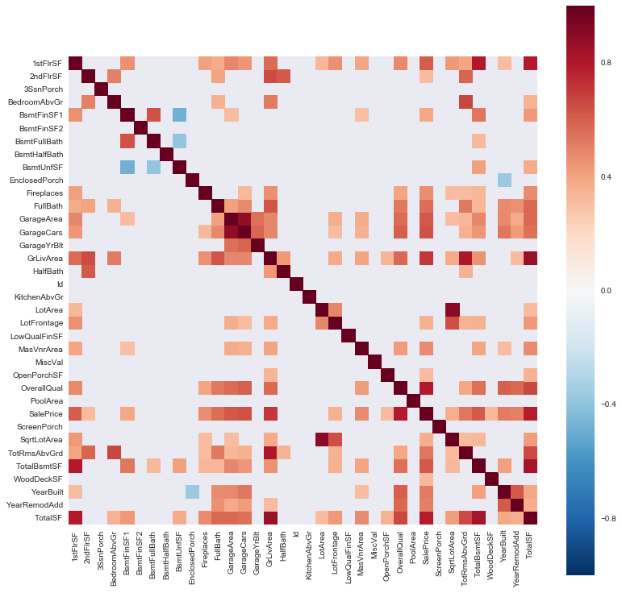

```python
#correlation matrix
corrmat = df.corr()

c = corrmat[(abs(corrmat) > 0.3)]
f, ax = plt.subplots(figsize=(13,13))

sns.heatmap(c, vmax=1, square=True)
plt.style.use('fivethirtyeight')
```

[figure not shown]

```python
#saleprice correlation matrix
cols = corrmat.nlargest(14, 'SalePrice')['SalePrice'].index
cm = np.corrcoef(df[cols].values.T)

f, ax = plt.subplots(figsize=(10,10))
sns.set(font_scale=1.25)

hm = sns.heatmap(cm, cbar=True, annot=True,cmap='Blues', square=True, fmt='.2f', annot_kws={'size': 10}, yticklabels=cols.values, xticklabels=cols.values)
plt.style.use('fivethirtyeight')
plt.show()
```

**The Housing Price(SalePrice) correlates strongly with the list of features.**  
**<font color=blue>['TotalSF','OverallQual', 'GrLivArea', 'GarageCars', 'GarageArea','TotalBsmtSF', '1stFlrSF', 'FullBath', 'TotRmsAbvGrd', 'YearBuilt']</font>**  
**But there is strong correlation among some of the features itself.**

## Categorical variables

**I further divided Categorical Variables into Ordered and Non-Ordered features**

**Features which have Ranks or Sequential values are Ordered and rest are Non-ordered**

### Ordered Categorical features

```python
from sklearn.preprocessing import LabelEncoder

cols = ('FireplaceQu', 'BsmtQual', 'BsmtCond', 'GarageQual', 'GarageCond',
        'ExterQual', 'ExterCond','HeatingQC', 'KitchenQual', 'BsmtFinType1',
        'BsmtFinType2', 'Functional', 'Fence', 'BsmtExposure', 'GarageFinish',
        'PavedDrive','PoolQC','Utilities','OverallCond')

# process columns, apply LabelEncoder to categorical features

for c in cols:
    lbl = LabelEncoder()
    lbl.fit(list(df[c].values))
    df[c] = lbl.transform(list(df[c].values))

# shape
print('Shape all_data: {}'.format(df.shape))
```

```
Shape all_data: (2919, 83)
```

### Non-Ordered Categorical features

```python
# non ordered
df = pd.get_dummies(df,columns=["Alley","BldgType","CentralAir",
"Condition1","Condition2","Electrical","Exterior1st","Exterior2nd","Foundation",
"GarageType","Heating","HouseStyle","LandContour","LandSlope","LotConfig","LotShape",
"MSZoning","MasVnrType","MiscFeature","Neighborhood","RoofMatl","RoofStyle",
"SaleCondition","SaleType","Street","MSSubClass","MoSold","YrSold"],drop_first=True)
```

```python
df = df.drop(labels=['MSSubClass_150','Condition2_PosN','MSSubClass_160'],axis = 1)
```

## Numerical (Continuous variables)

**In Numerical Continuous variables, I analyzed the Distribution and Linear Correlation with the Price variable**

```
OverallQual: Rates the overall material and finish of the house



       10	Very Excellent

       9	Excellent

       8	Very Good

       7	Good

       6	Above Average

       5	Average

       4	Below Average

       3	Fair

       2	Poor

       1	Very Poor
```

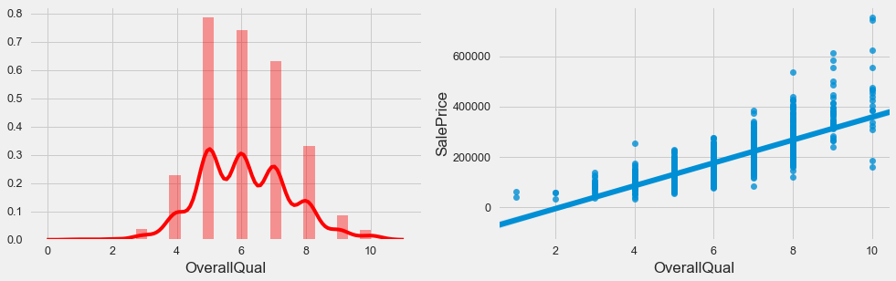

```
------------------------------------------------------------------------------------------------------------------------------
GrLivArea: Above grade (ground) living area square feet
```

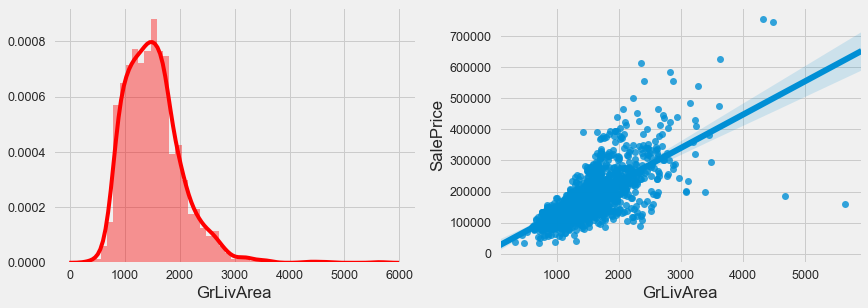

```
------------------------------------------------------------------------------------------------------------------------------
GarageCars: Size of garage in car capacity
```

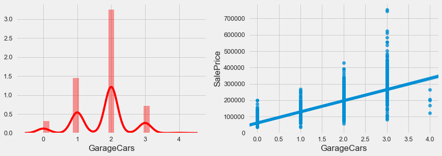

```
------------------------------------------------------------------------------------------------------------------------------
GarageArea: Size of garage in square feet
```

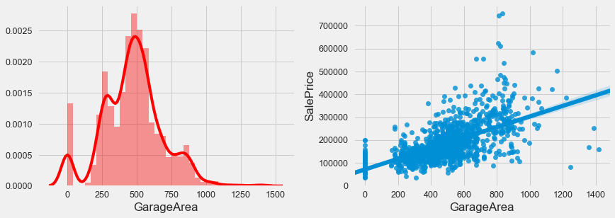

```
------------------------------------------------------------------------------------------------------------------------------
TotalBsmtSF: Total square feet of basement area
```

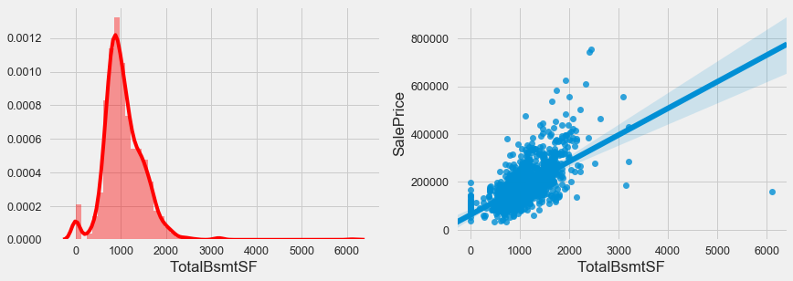

```
------------------------------------------------------------------------------------------------------------------------------
1stFlrSF: First Floor square feet
```

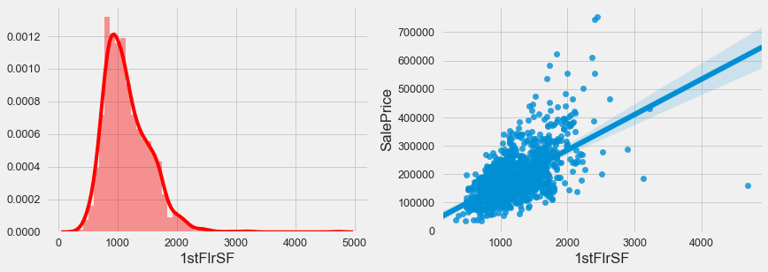

[output not shown]

[figure not shown]

```
------------------------------------------------------------------------------------------------------------------------------
FullBath: Full bathrooms above grade
```

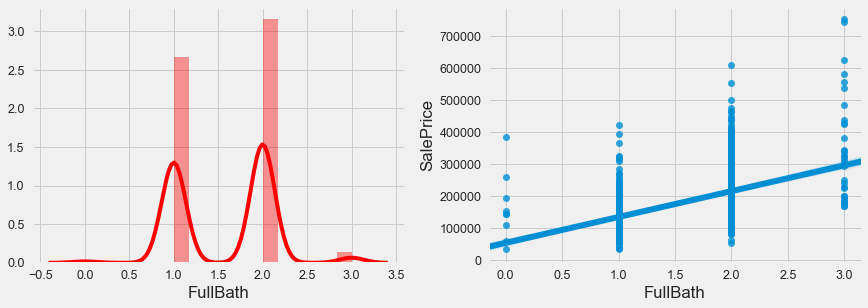

```
------------------------------------------------------------------------------------------------------------------------------
TotRmsAbvGrd: Total rooms above grade (does not include bathrooms)
```

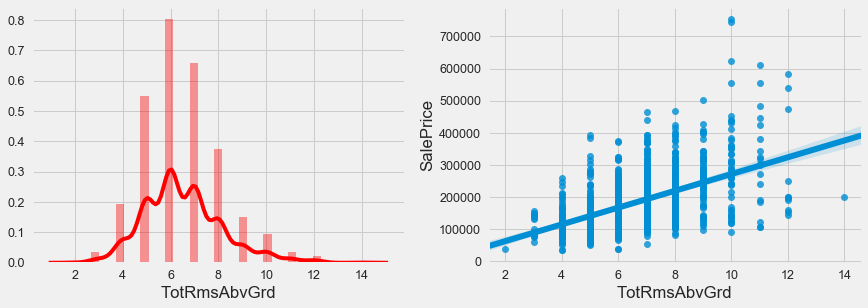

```python
cols = df.corr().nlargest(10, 'SalePrice')['SalePrice'].index
for a in cols:
    info_num(content,a,train_df,'SalePrice')
```

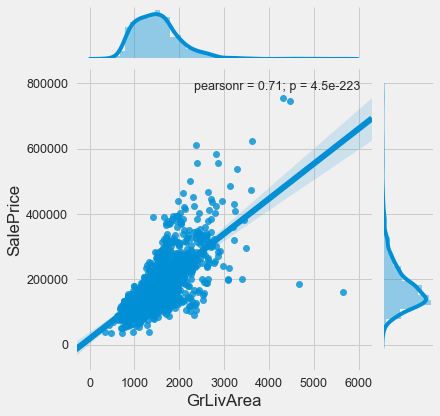

```python
g = sns.jointplot(x = df['GrLivArea'], y = df['SalePrice'],kind="reg")
```

**On detailed inspection, I saw that 2 bottom-rights points in "GrLivArea" are most likely Outliers**

```python
# Remove outliers manually (Two points in the bottom right)

df = df.drop(df[(df['GrLivArea']>4000) & (df['SalePrice']<300000) & (df['SalePrice'].notnull())].index).reset_index(drop=True)
ID = df['Id']
df.drop("Id", axis = 1, inplace = True)
```

```python
df[df['SalePrice'].isnull()].shape
```

```
(1459, 232)
```

### Normalization of data - Reduce skewness

**Next I analyzed the Skewness of each Numerical Variables**

### SalePrice

```
count      1458.000000
mean     180932.919067
std       79495.055285
min       34900.000000
25%      129925.000000
50%      163000.000000
75%      214000.000000
max      755000.000000
Name: SalePrice, dtype: float64
```

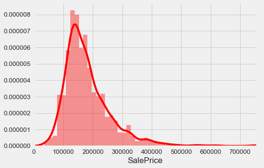

```python
# SalePrice - the property's sale price in dollars. This is the target variable that we're trying to predict.
print(df['SalePrice'].describe())

sns.set(font_scale=1.32)
style.use('fivethirtyeight')

facet = sns.FacetGrid( df ,aspect=1.5 ,palette = 'bright',size =5 )
facet.map(sns.distplot , 'SalePrice' ,color = 'r')
facet.set(xlim=( 0 , df['SalePrice'].max()))
facet.add_legend()
```

**I noticed that SalePrice feature has a positive skewnes(right skewed).**  
**Since linear regression models usually perform better on normally distributed data,I transformed this distribution to a normal one.**  
**I did this by taking the log of the data**

```
count    1458.000000
mean       12.024015
std         0.399713
min        10.460271
25%        11.774720
50%        12.001512
75%        12.273736
max        13.534474
Name: SalePrice, dtype: float64
```

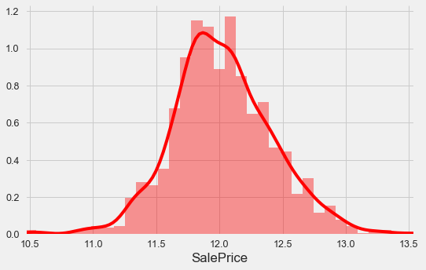

```python
df['SalePrice'] = np.log1p(df['SalePrice'])
print(df['SalePrice'].describe())

sns.set(font_scale=1.25)
style.use('fivethirtyeight')

facet = sns.FacetGrid( df ,aspect=1.5 ,palette = 'bright',size =5 )
facet.map(sns.distplot , 'SalePrice' ,color = 'r')
facet.set(xlim=( df['SalePrice'].min(), df['SalePrice'].max()))
facet.add_legend()
```

```python
Y = df["SalePrice"]
df = df.drop(labels="SalePrice",axis = 1)
```

**Similarly I analyzed the Normal distributions for other numerical variables**

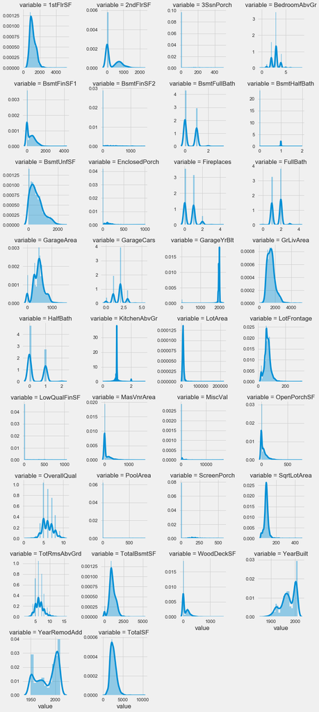

```python
f = pd.melt(df, value_vars=num_var)

style.use('fivethirtyeight')
g = sns.FacetGrid(f, col="variable",  col_wrap=4, sharex=False, sharey=False)

g = g.map(sns.distplot, "value")
```

**I checked the Skewness of each variable to find variables with highest skewness**

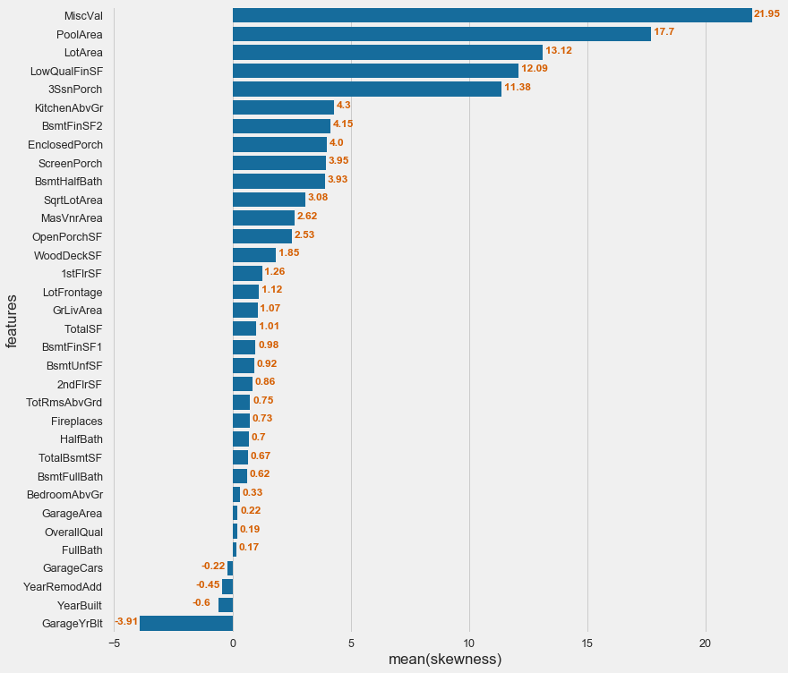

```python
sk = []
for a in num_var:
    b = df[a].skew()
    sk.append(b)

Skewness = pd.DataFrame({'features':num_var,'skewness':sk})
Skewness = Skewness.round(2)
Skewness.sort_values(by='skewness',ascending=False,inplace=True)
f, ax1 = plt.subplots(figsize=(12,12))
sns.barplot(x="skewness", y="features", data=Skewness,color = [0,114/255,178/255],ax=ax1)

# Add some data labels
y = Skewness['skewness'].tolist()

for i, v in enumerate(y):
    if v > 0:
        ax1.text(v+0.1, i+0.05, str(v), color=[213/255,94/255,0],fontsize= 12,fontweight='bold')
    else:
        ax1.text(v-1.1, i+0.05, str(v), color=[213/255,94/255,0],fontsize= 12,fontweight='bold')
```

```python
from scipy.special import boxcox1p
#Skewness = Skewness[Skewness['features']!='LotFrontage']
Skewness = Skewness[abs(Skewness['skewness']) > 0.75]

skewed_features = Skewness['features'].tolist()
print("There are {} highly skewed numerical features".format(len(skewed_features)))

for feature in skewed_features:
    lamda = 0.15
    df[feature] = boxcox1p(df[feature], lamda)
    df[feature] += 1
```

```
There are 22 highly skewed numerical features
```

**22 of 34 variables were highly skewed. So I normalized them using the Box-Cox Normalization**

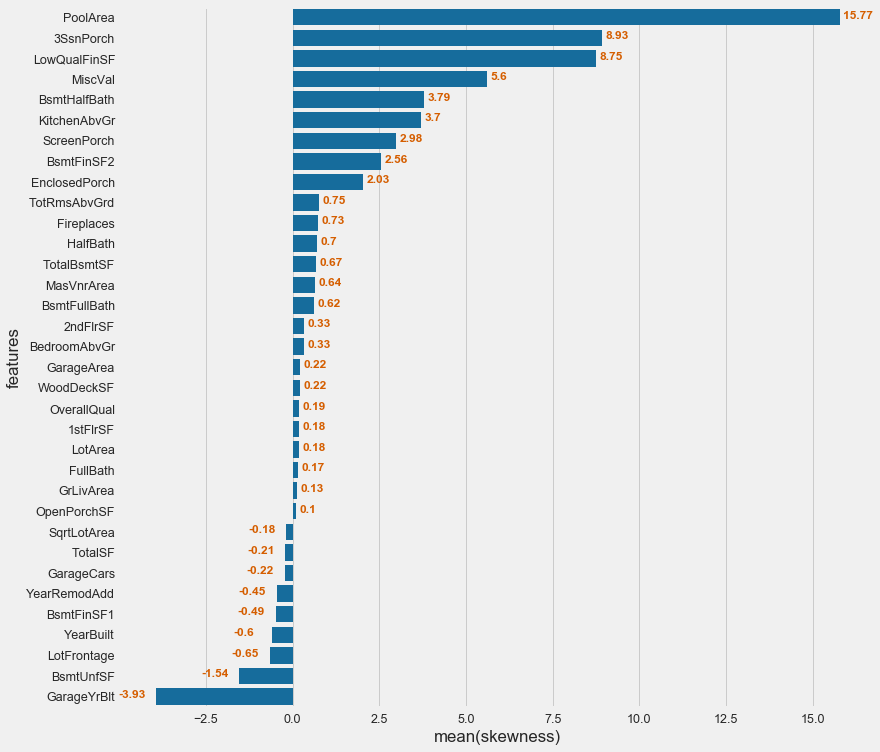

```python
sk = []
for a in num_var:
    b = df[a].skew()
    sk.append(b)
len(sk)
Skewness = pd.DataFrame({'features':num_var,'skewness':sk})
Skewness = Skewness.round(2)
Skewness.sort_values(by='skewness',ascending=False,inplace=True)
f, ax1 = plt.subplots(figsize=(12,12))
sns.barplot(x="skewness", y="features", data=Skewness,color = [0,114/255,178/255],ax=ax1)

# Add some data labels
y = Skewness['skewness'].tolist()

for i, v in enumerate(y):
    if v > 0:
        ax1.text(v+0.1, i+0.05, str(v), color=[213/255,94/255,0],fontsize= 12,fontweight='bold')
    else:
        ax1.text(v-1.1, i+0.05, str(v), color=[213/255,94/255,0],fontsize= 12,fontweight='bold')
```

**I left filling the missing values of<font color=blue> "LotFrontage" </font> from the Data Cleaning part**  
**Now that I have all the variables cleaned, I can predict missing LotFrontage data using Linear Regression**

```python
#Import Packages for Regression
from sklearn.linear_model import LinearRegression,LassoCV, Ridge, LassoLarsCV,ElasticNetCV
from sklearn.model_selection import GridSearchCV, cross_val_score, learning_curve
from sklearn.ensemble import RandomForestRegressor, AdaBoostRegressor, ExtraTreesRegressor, GradientBoostingRegressor
```

```python
# Predict LotFrontage with other descriptors using a LassoCV Regression model
train_LotF = df[df['LotFrontage'].notnull()]
test_LotF = df[df['LotFrontage'].isnull()]
Y_train_LotF = train_LotF['LotFrontage']
X_train_LotF = train_LotF.drop('LotFrontage',axis=1)
Y_train_LotF = np.log1p(Y_train_LotF)  # Log transform the LotF data
X_train_LotF.shape,Y_train_LotF.shape
```

```
((2431, 230), (2431,))
```

```python
# Get data to predict (LotFrontage missing)
X_test_LotF = test_LotF.drop('LotFrontage',axis=1)
```

```python
lassocv = LassoCV(eps=1e-8)

cv_results = cross_val_score(lassocv,X_train_LotF,Y_train_LotF,cv=5,scoring="r2",n_jobs=4)
cv_results.mean()
```

```
0.77160363047210068
```

**The Cross-Validation score comes as 0.77, which is pretty good.**

```python
lassocv.fit(X_train_LotF,Y_train_LotF)

LotF_pred = lassocv.predict(X_test_LotF)

df.loc[df['LotFrontage'].isnull(),'LotFrontage'] = LotF_pred
```

```python
df['SalePrice'] = Y
df['Id'] = ID
```

**I saved the final dataframe to csv file to be used later for modelling**

```python
df.to_csv('Model_house_data.csv',index=False)
```